# RNA_parte_1

YofreH

2025-09-19

# Tipos de capas en **TensorFlow/Keras**,

Las capas (`layers`) son los **bloques de construcción** de una red neuronal. **Guía organizada** con los tipos de capas más usados, su función y en qué casos se recomiendan.

# 🔹 1. Capas densas (fully connected)

```python
tf.keras.layers.Dense(units, activation='relu')
```

- **Qué hace**: conecta cada neurona de entrada con todas las de salida (clásico perceptrón multicapa).
- **Usos recomendados**:
  - Clasificación o regresión con datos tabulares.
  - Capas finales en CNNs o RNNs para tomar la decisión.

# 🔹 2. Capas de convolución

```python
tf.keras.layers.Conv2D(filters, kernel_size, activation='relu')
tf.keras.layers.Conv1D(...)
tf.keras.layers.Conv3D(...)
```

- **Qué hacen**: detectan patrones locales mediante filtros (ventanas deslizantes).
- **Usos recomendados**:
  - **Conv2D** → imágenes.
  - **Conv1D** → series temporales, audio, texto secuencial.
  - **Conv3D** → videos o volúmenes 3D (p.ej. imágenes médicas).

# 🔹 3. Capas de pooling (reducción de dimensión)

```python
tf.keras.layers.MaxPooling2D(pool_size=2)
tf.keras.layers.AveragePooling2D(...)
tf.keras.layers.GlobalAveragePooling2D()
```

- **Qué hacen**: reducen el tamaño de la representación manteniendo información importante.
- **Usos recomendados**:
  - Evitar overfitting en CNNs.
  - Hacer redes más rápidas y compactas.

# 🔹 4. Capas recurrentes

```python
tf.keras.layers.SimpleRNN(units)
tf.keras.layers.LSTM(units)
tf.keras.layers.GRU(units)
```

- **Qué hacen**: mantienen memoria sobre secuencias.
- **Usos recomendados**:
  - Procesamiento de texto secuencial.
  - Series temporales (predicciones de demanda, clima, etc.).
  - LSTM y GRU son preferidas porque resuelven mejor el problema del gradiente desvanecido que SimpleRNN.

# 🔹 5. Capas de embeddings

```python
tf.keras.layers.Embedding(input_dim, output_dim)
```

- **Qué hace**: convierte categorías o palabras en vectores densos de baja dimensión.
- **Usos recomendados**:
  - NLP (representación de palabras, frases).
  - Datos categóricos con muchas clases (ej. códigos de producto).

# 🔹 6. Capas de normalización

```python
tf.keras.layers.BatchNormalization()
tf.keras.layers.LayerNormalization()
```

- **Qué hacen**: reescalan activaciones para estabilizar entrenamiento.
- **Usos recomendados**:
  - Redes profundas (CNNs, RNNs, Transformers).
  - Aceleran la convergencia y reducen sensibilidad a inicialización.

# 🔹 7. Capas de regularización

```python
tf.keras.layers.Dropout(rate=0.5)
tf.keras.layers.SpatialDropout2D(rate=0.2)
```

- **Qué hacen**: apagan neuronas aleatoriamente durante entrenamiento.
- **Usos recomendados**:
  - Cuando hay riesgo de **overfitting**.
  - Dropout clásico en densas, SpatialDropout en CNNs.

# 🔹 8. Capas de activación

```python
tf.keras.layers.Activation('relu')
```

- **Qué hacen**: aplican funciones no lineales (ReLU, sigmoid, tanh, softmax…).
- **Usos recomendados**:
  - ReLU → capas ocultas.
  - Sigmoid → clasificación binaria.
  - Softmax → clasificación multiclase.
  - Tanh → algunas RNNs.

# 🔹 9. Capas especiales de TensorFlow

- **Attention / MultiHeadAttention**:

  ```python
  tf.keras.layers.MultiHeadAttention(num_heads=8, key_dim=64)
  ```

  → Base de los Transformers (NLP, visión).
- **Reshape, Flatten, Concatenate**: manipulan la forma de los tensores.
- **ConvLSTM2D**: combina convolución y memoria → videos, secuencias de imágenes.

# 🔹 10. Capas de salida típicas

- **Clasificación binaria**: `Dense(1, activation='sigmoid')`
- **Clasificación multiclase**: `Dense(n_clases, activation='softmax')`
- **Regresión**: `Dense(1, activation=None)`

¡Excelente! Vamos a profundizar en **la capa de convolución 2D (`Conv2D`)**, que es fundamental en redes neuronales convolucionales (CNNs). Te doy tres cosas: **explicación detallada**, **dibujo conceptual** y **ejemplo interpretativo (sin código)**.

# 🔹 2. ¿Qué es una capa `Conv2D`?

Es una capa que aplica **filtros (kernels)** sobre una entrada bidimensional (imagen, mapa de características, etc.) para detectar patrones locales. Cada filtro es una **ventana deslizante** que se mueve sobre la entrada multiplicando y sumando valores → genera un **mapa de activación**.

# 🔹 2.2. Forma y parámetros principales

- **filters** → número de filtros (cuántos mapas de activación se generan).
- **kernel_size** → tamaño de cada filtro (ej. 3×3, 5×5).
- **strides** → cuántos píxeles se mueve el filtro cada vez.
- **padding** → si se rellenan los bordes (“same”) o no (“valid”).
- **activation** → función no lineal aplicada al resultado (ej. ReLU).

# 🔹 2.3. Dibujo conceptual

Imagina una **imagen de entrada** de 5×5 píxeles en escala de grises (un solo canal):

```
Entrada (5x5)
[ 1  2  3  0  1 ]
[ 0  1  2  3  1 ]
[ 3  2  1  0  2 ]
[ 2  0  1  2  3 ]
[ 1  1  0  2  1 ]
```

Y un **filtro 3×3** (ejemplo detecta bordes):

```
Kernel (3x3)
[-1  0  1]
[-1  0  1]
[-1  0  1]
```

Cuando el filtro se “desliza” sobre la imagen:

- Se multiplica elemento a elemento (convolución).
- Se suman los resultados.
- Se obtiene un **nuevo valor** en la salida.

# 🔹 2.4. Ejemplo interpretativo (sin programar)

Supón que usamos:

```
Conv2D(filters=2, kernel_size=(3,3), strides=(1,1), padding="valid", activation="relu")
```

### a) Entrada

Una foto en escala de grises de 28×28 (como MNIST).

### b) Proceso

- **filters=2** → usaremos 2 filtros distintos (p. ej. uno detecta bordes verticales, otro detecta bordes horizontales).
- **kernel_size=(3,3)** → cada filtro observa “ventanas” de 3×3 píxeles.
- **strides=(1,1)** → el filtro se mueve 1 pixel cada vez (máxima resolución).
- **padding=“valid”** → no se agregan bordes, así que la salida es de 26×26 (más pequeña que la entrada).
- **activation=“relu”** → convertimos los valores negativos en 0, conservando solo activaciones fuertes.

### c) Salida

- Cada filtro genera un mapa de activación de 26×26.
- Con 2 filtros, obtenemos una salida de **26×26×2**.

Interpretación:

- El primer mapa ilumina dónde hay bordes verticales en la imagen.
- El segundo mapa ilumina dónde hay bordes horizontales.
- Estos mapas se usan como **entrada a capas posteriores**, que combinan patrones básicos en estructuras más complejas (esquinas, formas, objetos).

# 🔹 2.5. Analogía intuitiva para compreder su uso

- Piensa en la imagen como un **texto escrito en papel**.
- Los filtros son como **marcadores transparentes**: uno que resalta solo las **líneas horizontales**, otro solo las **verticales**.
- Al pasar estos filtros por el texto, obtienes “mapas” que muestran solo esas características.
- Cuantas más capas añades, más complejo es lo que detectas (bordes → formas → dígitos → rostros).

# **Mini–ejemplo numérico paso a paso de una convolución 2D**.

# 🔹 1. Entrada

Imaginemos una **imagen 4×4 en escala de grises** (cada número es la intensidad de un píxel):

$$X =
\begin{bmatrix}
1 & 2 & 0 & 1 \\
3 & 1 & 2 & 2 \\
0 & 1 & 3 & 1 \\
2 & 0 & 1 & 1
\end{bmatrix}$$

# 🔹 2. Filtro (kernel)

Usaremos un **filtro 2×2** que actúa como **detector de bordes**:

$$K =
\begin{bmatrix}
1 & -1 \\
1 & -1
\end{bmatrix}$$

# 🔹 3. Proceso de convolución

- **Stride = (1,1)** → el filtro se mueve de 1 en 1.
- **Padding = valid** → no se agregan bordes, así que la salida será de tamaño $(4-2+1)\times(4-2+1) = 3\times 3$.

👉 Para cada posición:

$$(X \odot K)_{i,j} = \sum_{u,v} X_{i+u,\,j+v} \cdot K_{u,v}$$

# 🔹 4. Cálculos paso a paso

### (a) Primera ventana (esquina superior izquierda):

$$\begin{bmatrix}
1 & 2 \\
3 & 1
\end{bmatrix}
\cdot
\begin{bmatrix}
1 & -1 \\
1 & -1
\end{bmatrix}
= (1\cdot1) + (2\cdot -1) + (3\cdot1) + (1\cdot -1)$$

$$= 1 - 2 + 3 - 1 = 1$$

### (b) Segunda ventana (fila 1, columna 2):

$$\begin{bmatrix}
2 & 0 \\
1 & 2
\end{bmatrix}
\cdot
\begin{bmatrix}
1 & -1 \\
1 & -1
\end{bmatrix}
= (2\cdot1) + (0\cdot -1) + (1\cdot1) + (2\cdot -1)$$

$$= 2 + 0 + 1 - 2 = 1$$

### (c) Tercera ventana (fila 1, columna 3):

$$\begin{bmatrix}
0 & 1 \\
2 & 2
\end{bmatrix}
\cdot
\begin{bmatrix}
1 & -1 \\
1 & -1
\end{bmatrix}
= (0\cdot1) + (1\cdot -1) + (2\cdot1) + (2\cdot -1)$$

$$= 0 - 1 + 2 - 2 = -1$$

# 🔹 5. Resultado completo

# 🔹 6. Interpretación

- Los valores positivos indican coincidencias fuertes con el patrón del kernel (bordes en cierta dirección).
- Los valores negativos indican la presencia del patrón contrario.
- Si aplicamos una **ReLU**, los negativos se vuelven 0, quedando solo las activaciones relevantes.

# **RNA: Perceptrón Simple**

## Objetivo

- Entender **qué es** un perceptrón simple.
- Visualizar su **ecuación** y su **interpretación geométrica**.
- Ver **cuándo funciona** y **cuándo falla** (AND vs XOR).
- Conectar posteriormente con redes más profundas → Conv2D.

## ¿Qué es el perceptrón?

El **perceptrón** (Rosenblatt, 1958) es el modelo más simple de neurona artificial.

$$y = f\Big(\underbrace{\sum_{i=1}^{n} w_i x_i}_{\text{combinación
lineal}} + b\Big)$$

- $x_i$: características de entrada
- $w_i$: pesos (importancia)
- $b$: sesgo (umbral)
- $f$: activación (p.ej., *step*, *sigmoid*, ReLU)

**Idea**: aprende una **frontera lineal** que separa dos clases.

## Intuición geométrica

- En 2D aprende una **recta**; en 3D, un **plano**; en general, un **hiperplano**.
- Clasifica según el **lado** de la frontera donde cae el punto.

$$\underbrace{w_1 x_1 + w_2 x_2 + b = 0}_{\text{frontera de decisión}}$$

## Ejemplo: compuerta AND

Tabla de verdad:

| $x_1$ | $x_2$ | $y$ |
| --- | --- | --- |
| 0 | 0 | 0 |
| 0 | 1 | 0 |
| 1 | 0 | 0 |
| 1 | 1 | 1 |

> El perceptrón **sí** puede separar AND con una recta.

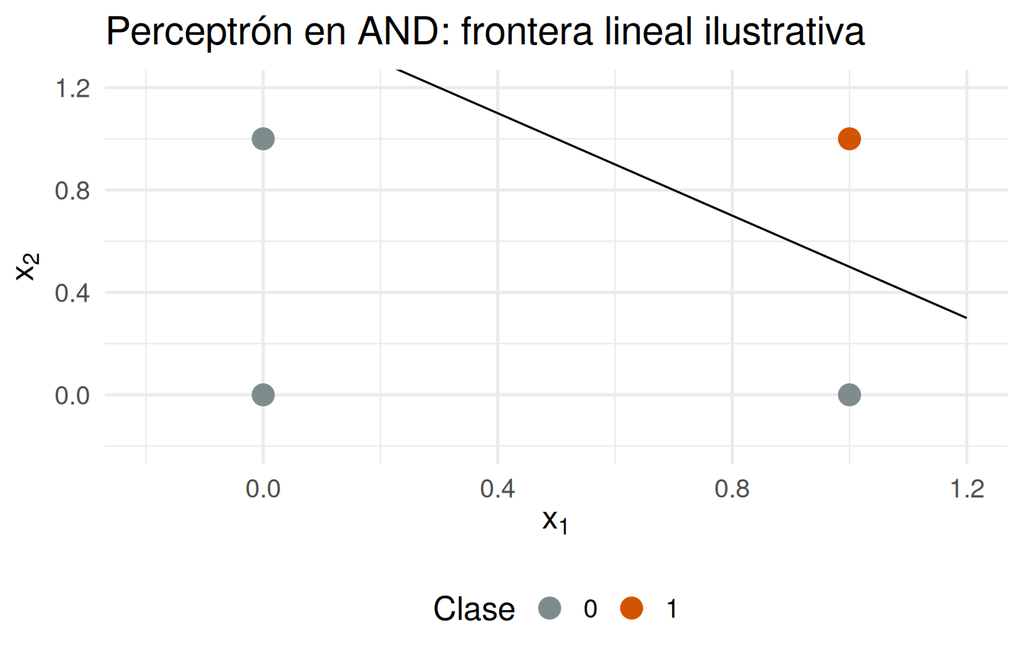

## ¿Por qué la activación?

Sin activación, el modelo es **lineal** de extremo a extremo. Con activación (sigmoid/ReLU), la neurona puede **aprender umbrales** y producir **probabilidades**:

- `sigmoid(z) = 1/(1 + e^{-z})` → salida en (0,1).
- `ReLU(z) = max(0, z)` → útil en redes profundas.

## ¿Cuándo falla? XOR

Tabla XOR:

| $x_1$ | $x_2$ | $y$ |
| --- | --- | --- |
| 0 | 0 | 0 |
| 0 | 1 | 1 |
| 1 | 0 | 1 |
| 1 | 1 | 0 |

> XOR **no es linealmente separable** → un perceptrón simple **no puede** resolverlo.

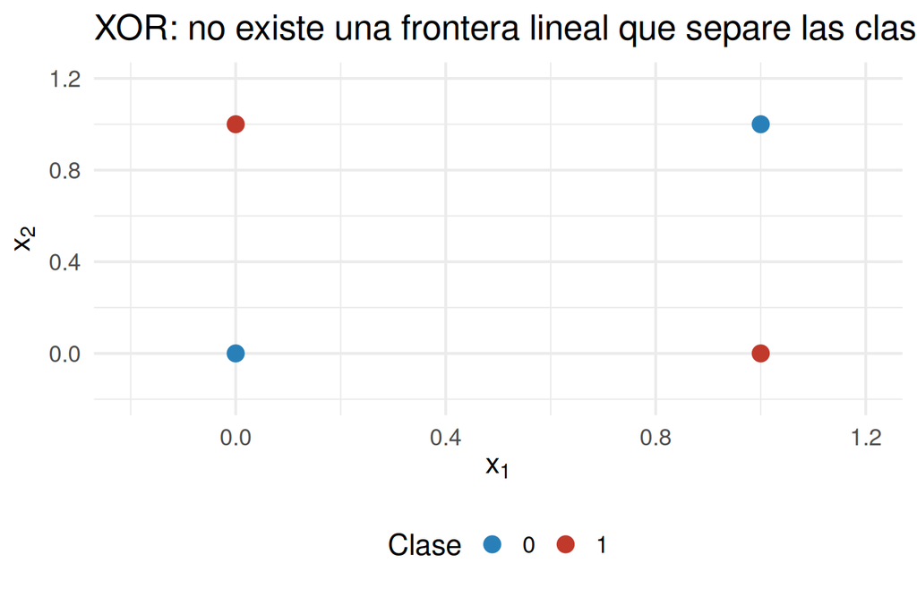

## Componentes y efecto en la frontera

- **Pesos $w$**: rotan/inclinan la frontera.
- **Sesgo $b$**: traslada la frontera.
- **Tasa de aprendizaje** (en entrenamiento): qué tan rápido cambian $w,b$.
- **Pérdida** (p.ej., *binary cross-entropy*): mide el error de clasificación probabilística.

## Conexión con el taller (Colab)

1. Entrenar un perceptrón en **AND** (Bloque 1).
2. Visualizar **pesos y fronteras**.
3. Notar la limitación: **XOR**.
4. **Próximo bloque**: **MLP** (capas densas adicionales) → combina neuronas para fronteras no lineales.
5. Luego, datos de **imágenes** y **Conv2D**.

## Cierre

- El perceptrón es la **unidad elemental**.
- Su límite (separación lineal) **motiva** redes más profundas.
- Esta base conceptual es clave antes de entrar a **CNNs (Conv2D)**.

## Referencias breves

- Rosenblatt, F. (1958). *The perceptron: A probabilistic model for information storage and organization in the brain*.
- Goodfellow, I., Bengio, Y., Courville, A. (2016). *Deep Learning*. MIT Press.
- Bishop, C. M. (2006). *Pattern Recognition and Machine Learning*. Springer.

Excelente observación — sí: el entrenamiento de una red neuronal puede formularse como un **problema de optimización sin restricciones**, pero con una estructura muy específica. Vamos a **reformular el planteamiento general** con todas las variables definidas y ejemplos concretos de la función de pérdida.

## 🔹 Planteamiento matemático general

### ✳️ Definición de cada símbolo

[output not shown]

## 🔹 ¿Por qué es un problema sin restricciones?

Sin embargo, sí existen **restricciones implícitas**:

- Los pesos (W) están determinados por las **dimensiones de las capas**.
- Las **funciones de activación** (ReLU, Sigmoid, etc.) introducen **no linealidad**.
- En la práctica, se usa **regularización** para evitar soluciones no deseadas (esto se incorpora al funcional, no como restricción).

Por tanto, el problema es **sin restricciones explícitas**, pero **estructuralmente no convexo** y de **alta dimensión**.

### 1. **Regresión (salida real)**

> Mide el error cuadrático medio (MSE). Ejemplo: predecir temperatura, precio o valor continuo.

### 2. **Clasificación binaria (salida en ([0,1]))**

> Es la **entropía cruzada binaria**, usada en redes con activación **sigmoide** en la salida.